# ISE 224 Lab 10

## Useful packages: Pandas and Matplotlib

### Problem 1

Using the `pandas` package, open the 'Airports.xlsx' file, and copy the data where 'Origin_airport' equals 'MIA' and the 'Distance' is greater than 1000 to a new Excel file named 'output1.xlsx'.

```python
import pandas as pd
import matplotlib.pyplot as plt
import time
```

```python
start = time.time()
dat = pd.read_excel('Airports.xlsx')
end = time.time()
print(end - start)
```

```
69.19606328010559
```

```python
dat.head()
```

|  | SID | Origin_airport | Destination_airport | Origin_city | Destination_city | Passengers | Seats | Flights | Distance | Fly_date | Origin_population | Destination_population | Org_airport_lat | Org_airport_long | Dest_airport_lat | Dest_airport_long |
| --- | --- | --- | --- | --- | --- | --- | --- | --- | --- | --- | --- | --- | --- | --- | --- | --- |
| 0 | 1 | MHK | AMW | Manhattan, KS | Ames, IA | 21 | 30 | 1 | 254 | 2008-10-01 | 122049 | 86219 | 39.140999 | -96.670799 | NaN | NaN |
| 1 | 1012 | EUG | RDM | Eugene, OR | Bend, OR | 22 | 70 | 1 | 103 | 2006-12-01 | 339280 | 148670 | 44.124599 | -123.211998 | 44.254101 | -121.150002 |
| 2 | 1013 | EUG | RDM | Eugene, OR | Bend, OR | 62 | 150 | 1 | 103 | 2006-12-01 | 339280 | 148670 | 44.124599 | -123.211998 | 44.254101 | -121.150002 |
| 3 | 1014 | EUG | RDM | Eugene, OR | Bend, OR | 583 | 2220 | 30 | 103 | 2006-08-01 | 339280 | 148670 | 44.124599 | -123.211998 | 44.254101 | -121.150002 |
| 4 | 1015 | EUG | RDM | Eugene, OR | Bend, OR | 605 | 2220 | 30 | 103 | 2006-10-01 | 339280 | 148670 | 44.124599 | -123.211998 | 44.254101 | -121.150002 |

```python
dat.tail()
```

|  | SID | Origin_airport | Destination_airport | Origin_city | Destination_city | Passengers | Seats | Flights | Distance | Fly_date | Origin_population | Destination_population | Org_airport_lat | Org_airport_long | Dest_airport_lat | Dest_airport_long |
| --- | --- | --- | --- | --- | --- | --- | --- | --- | --- | --- | --- | --- | --- | --- | --- | --- |
| 505841 | 2049996 | PHX | CLT | Phoenix, AZ | Charlotte, NC | 13705 | 15372 | 84 | 1774 | 2008-09-01 | 4287323 | 1706469 | 33.434299 | -112.012001 | 35.214001 | -80.9431 |
| 505842 | 2049997 | RDU | CLT | Raleigh, NC | Charlotte, NC | 350 | 430 | 5 | 130 | 2008-11-01 | 1090408 | 1706469 | 35.877602 | -78.787498 | 35.214001 | -80.9431 |
| 505843 | 2049998 | RDU | CLT | Raleigh, NC | Charlotte, NC | 319 | 370 | 10 | 130 | 2008-12-01 | 1090408 | 1706469 | 35.877602 | -78.787498 | 35.214001 | -80.9431 |
| 505844 | 2049999 | RDU | CLT | Raleigh, NC | Charlotte, NC | 40 | 50 | 1 | 130 | 2008-12-01 | 1090408 | 1706469 | 35.877602 | -78.787498 | 35.214001 | -80.9431 |
| 505845 | 2050000 | CAE | CLT | Columbia, SC | Charlotte, NC | 89 | 100 | 2 | 88 | 2008-07-01 | 732558 | 1706469 | 33.938801 | -81.119499 | 35.214001 | -80.9431 |

```python
df1 = dat.loc[(dat['Origin_airport']=="MIA") & (dat['Distance']>1000),:]
```

```python
df1.to_excel('output1.xlsx')
```

### Problem 2

Using the `pandas` package, open the 'Airports.xlsx' file and extract the information from the **SID**, **Destination_airport**, **Passengers**, and **Seats** columns where the 'Origin_airport' equals 'MIA' and the 'Distance' is greater than 1000. Save this information to a new Excel file named 'output2.xlsx'.

```python
import pandas as pd
import matplotlib.pyplot as plot
import time
```

```python
start = time.time()
dat = pd.read_excel('Airports.xlsx')
end = time.time()
print(end - start)
```

```
69.09281516075134
```

```python
df2 = dat.loc[(dat['Origin_airport']=="MIA") & (dat['Distance']>1000),['SID','Destination_airport','Passengers','Seats']]
df2.to_excel('output2.xlsx')
```

### Problem 3

To analyze the **Destination_airport** variable from the output of problem 2, we first count the frequency of each airport and create a **line plot** to visualize the data. The x-axis represents the airports, while the y-axis represents the frequency. We label the x-axis as "Airport" and the y-axis as "Frequency", and title the figure as "Destination Airport". To enhance the plot's aesthetics, we change the line color to **green**, the linestyle to **"dashdot"**, and the marker to **"^"**.

- Hint1: `pandas_obj.value_counts()` to get the frequency
- Hint2: `plt.plot(x, y)` for line plot

```python
df3 = df2['Destination_airport'].value_counts()
df3.head()
```

```
EWR    425
JFK    393
DFW    300
ORD    286
LGA    176
Name: Destination_airport, dtype: int64
```

```python
df3.index
```

```
Index(['EWR', 'JFK', 'DFW', 'ORD', 'LGA', 'DTW', 'BOS', 'ANC', 'SEA', 'BDL',
       'PHX', 'MDW', 'AUS', 'DAL', 'TOL', 'AFW', 'BUF', 'YIP', 'TUL', 'ELP',
       'GRK', 'RFD', 'TUS', 'OMA', 'OAK', 'ABE', 'SYR', 'BFI', 'BGR', 'LRD',
       'ALB', 'GYY', 'LBB', 'ABI', 'ROW', 'MSN', 'BIF', 'FTW', 'ADS', 'COU',
       'SJC', 'AVP', 'NFL', 'FWH', 'CAK', 'VCT', 'ELM', 'HNL', 'ACT', 'CYS',
       'GEG', 'AZA', 'LAW', 'LNK', 'PIA', 'PUB', 'SLN', 'TCM', 'FAT'],
      dtype='object')
```

```python
df3.values
```

```
array([425, 393, 300, 286, 176, 173, 120,  82,  65,  62,  50,  37,  30,
        18,  17,  16,  13,  11,   9,   8,   7,   6,   5,   4,   4,   3,
         3,   3,   3,   3,   3,   2,   2,   2,   2,   2,   2,   2,   2,
         2,   1,   1,   1,   1,   1,   1,   1,   1,   1,   1,   1,   1,
         1,   1,   1,   1,   1,   1,   1], dtype=int64)
```

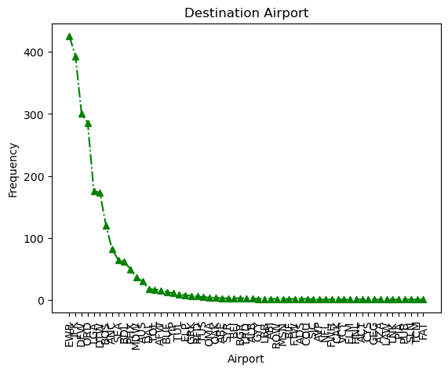

```python
plt.plot(df3.index, df3.values, color = "g", linestyle ="dashdot", marker = "^")
plt.title('Destination Airport')
plt.xlabel('Airport')
plt.ylabel('Frequency')
plt.xticks(rotation=90)
plt.show()
```

### Problem 4

To analyze the **Destination_airport** variable from problem 2, we count the frequency of each airport and create a **scatter plot** to visualize the data. The x-axis represents the airports, while the y-axis represents the frequency. We label the x-axis as "Airport" and the y-axis as "Frequency", and title the figure as "Destination Airport". Change the color to red, and marker to 's'.

- Hint1: `pandas_obj.value_counts()` to get the frequency
- Hint2: `fig=plt.figure()`,`ax=fig.add_axes([1,1,1,1])`,`ax.scatter(x, y)` for scatter plot
- Hint3: Use `plt.xticks(rotation=90)` to rotate the x tick labels.

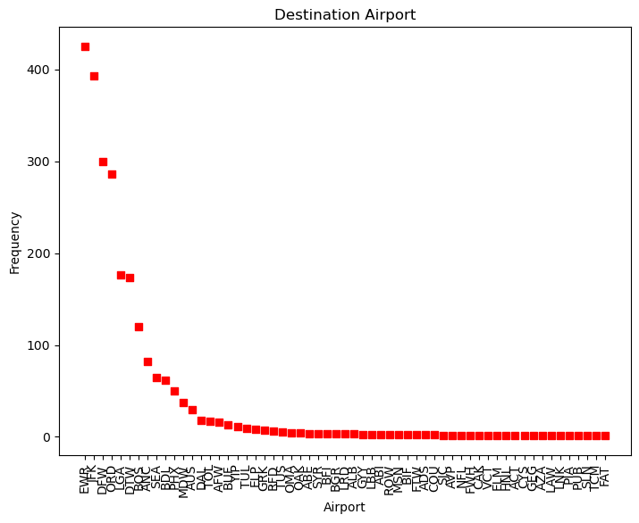

```python
fig = plt.figure()
ax = fig.add_axes([1, 1, 1, 1])
ax.scatter(df3.index, df3.values, color='r', marker="s")

ax.set_xlabel("Airport")
ax.set_ylabel("Frequency")
ax.set_title("Destination Airport")
plt.xticks(rotation=90)
plt.show()
```

### Problem 5

To analyze the **Destination_airport** variable from problem 2, we count the frequency of each airport and create a **bar chart** to visualize the data. The x-axis represents the airports, while the y-axis represents the frequency. We label the x-axis as "Airport" and the y-axis as "Frequency", and title the figure as "Destination Airport". Change the color to orange.

- Hint1: `pandas_obj.value_counts()` to get the frequency
- Hint2: `fig=plt.figure()`,`ax=fig.add_axes([1,1,1,1])`, `ax.bar(x, y)` for bar chart
- Hint3: Use `plt.xticks(rotation=90)` to rotate tick labels

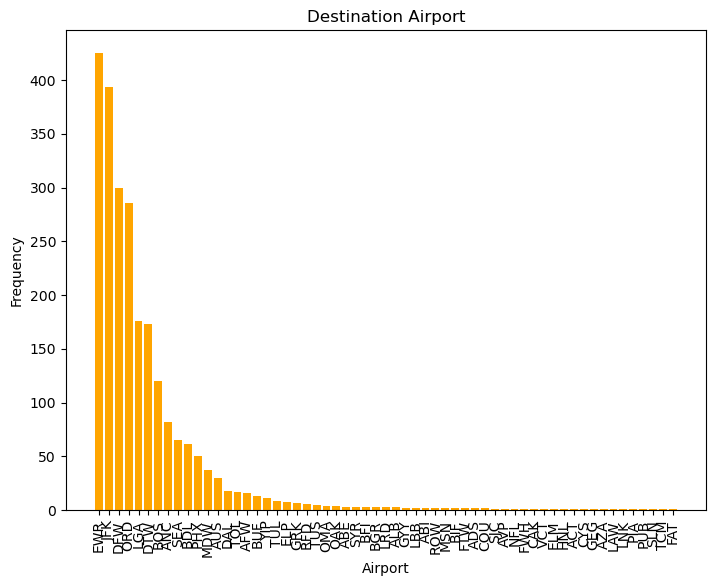

```python
fig = plt.figure()
ax = fig.add_axes([1, 1, 1, 1])
ax.bar(df3.index,df3.values,color="orange")


ax.set_xlabel("Airport")
ax.set_ylabel("Frequency")
ax.set_title("Destination Airport")
plt.xticks(rotation=90)
plt.show()
```